# Final Project

Nandagopal Panicker

[figure not shown]

Final Project: Spotify Image Analysis

## Research Objective

The aim of this project is to successfully compare two datasets to derive valuable insights from both of them. I have a couple of objectives in mind with regards to spotting trends:

- I want to find the top 5 songs appearing the most in playlists in 2023 and 2024 and make a vizualization revolving around the same.
- Since this is not a key feature in the 2024 dataset, I want to see if the bpm of a song has a correlation of sorts to how popular it is on the most popular streaming platform(Spotify).
- In addition to this, I want to compare the streams for songs over Spotify, Deezer, and Apple Music and see if the music in 2024 is more popular than the music in 2023.

## Data Processing

#### Data Intake

A couple of things are important to note with regards to these data-sets. The 2023 spotify dataset has a lot less data than the 2024 one.

Both these datasets have been provided by the Spotify API. For the sake of visualization and data preprocessing steps, we will take only the top 50 songs of each year of each dataset.

I have downloaded the two datasets from Kaggle, they are publicly available datasets with the links as follows:

[Click here for the link to the 2023 Spotify Dataset](https://www.kaggle.com/datasets/nelgiriyewithana/top-spotify-songs-2023)

[Click here for the link to the 2024 Spotify Dataset](https://www.kaggle.com/datasets/nelgiriyewithana/most-streamed-spotify-songs-2024?resource=download)

I have uploaded the csv files on the ‘Final Project’ Git repository, and pulled the files onto my local workspace.

#### Data Wrangling

Here are the libraries we need to use:

```r
library(tidyverse)
library(ggplot2)
```

```r
data2023 <- read.csv("spotify-2023.csv")
head(data1)
```

|  | track_name | artist.s._name | artist_count | released_year | released_month | released_day | in_spotify_playlists | in_spotify_charts | streams | in_apple_playlists | in_apple_charts | in_deezer_playlists | in_deezer_charts | in_shazam_charts | bpm | key | mode | danceability_. | valence_. | energy_. | acousticness_. | instrumentalness_. | liveness_. | speechiness_. |
| --- | --- | --- | --- | --- | --- | --- | --- | --- | --- | --- | --- | --- | --- | --- | --- | --- | --- | --- | --- | --- | --- | --- | --- | --- |
| 1 | Seven (feat. Latto) (Explicit Ver.) | Latto, Jung Kook | 2 | 2023 | 7 | 14 | 553 | 147 | 141381703 | 43 | 263 | 45 | 10 | 826 | 125 | B | Major | 80 | 89 | 83 | 31 | 0 | 8 | 4 |
| 2 | LALA | Myke Towers | 1 | 2023 | 3 | 23 | 1474 | 48 | 133716286 | 48 | 126 | 58 | 14 | 382 | 92 | C# | Major | 71 | 61 | 74 | 7 | 0 | 10 | 4 |
| 3 | vampire | Olivia Rodrigo | 1 | 2023 | 6 | 30 | 1397 | 113 | 140003974 | 94 | 207 | 91 | 14 | 949 | 138 | F | Major | 51 | 32 | 53 | 17 | 0 | 31 | 6 |
| 4 | Cruel Summer | Taylor Swift | 1 | 2019 | 8 | 23 | 7858 | 100 | 800840817 | 116 | 207 | 125 | 12 | 548 | 170 | A | Major | 55 | 58 | 72 | 11 | 0 | 11 | 15 |
| 5 | WHERE SHE GOES | Bad Bunny | 1 | 2023 | 5 | 18 | 3133 | 50 | 303236322 | 84 | 133 | 87 | 15 | 425 | 144 | A | Minor | 65 | 23 | 80 | 14 | 63 | 11 | 6 |
| 6 | Sprinter | Dave, Central Cee | 2 | 2023 | 6 | 1 | 2186 | 91 | 183706234 | 67 | 213 | 88 | 17 | 946 | 141 | C# | Major | 92 | 66 | 58 | 19 | 0 | 8 | 24 |

This is the head of the 2023 Spotify Most Streamed Charts.

```r
data2024 <- read.csv("Most Streamed Spotify Songs 2024.csv")
head(data2024)
```

|  | Track | Album.Name | Artist | Release.Date | ISRC | All.Time.Rank | Track.Score | Spotify.Streams | Spotify.Playlist.Count | Spotify.Playlist.Reach | Spotify.Popularity | YouTube.Views | YouTube.Likes | TikTok.Posts | TikTok.Likes | TikTok.Views | YouTube.Playlist.Reach | Apple.Music.Playlist.Count | AirPlay.Spins | SiriusXM.Spins | Deezer.Playlist.Count | Deezer.Playlist.Reach | Amazon.Playlist.Count | Pandora.Streams | Pandora.Track.Stations | Soundcloud.Streams | Shazam.Counts | TIDAL.Popularity | Explicit.Track |
| --- | --- | --- | --- | --- | --- | --- | --- | --- | --- | --- | --- | --- | --- | --- | --- | --- | --- | --- | --- | --- | --- | --- | --- | --- | --- | --- | --- | --- | --- |
| 1 | MILLION DOLLAR BABY | Million Dollar Baby - Single | Tommy Richman | 4/26/2024 | QM24S2402528 | 1 | 725.4 | 390,470,936 | 30,716 | 196,631,588 | 92 | 84,274,754 | 1,713,126 | 5,767,700 | 651,565,900 | 5,332,281,936 | 150,597,040 | 210 | 40,975 | 684 | 62 | 17,598,718 | 114 | 18,004,655 | 22,931 | 4,818,457 | 2,669,262 | NA | 0 |
| 2 | Not Like Us | Not Like Us | Kendrick Lamar | 5/4/2024 | USUG12400910 | 2 | 545.9 | 323,703,884 | 28,113 | 174,597,137 | 92 | 116,347,040 | 3,486,739 | 674,700 | 35,223,547 | 208,339,025 | 156,380,351 | 188 | 40,778 | 3 | 67 | 10,422,430 | 111 | 7,780,028 | 28,444 | 6,623,075 | 1,118,279 | NA | 1 |
| 3 | i like the way you kiss me | I like the way you kiss me | Artemas | 3/19/2024 | QZJ842400387 | 3 | 538.4 | 601,309,283 | 54,331 | 211,607,669 | 92 | 122,599,116 | 2,228,730 | 3,025,400 | 275,154,237 | 3,369,120,610 | 373,784,955 | 190 | 74,333 | 536 | 136 | 36,321,847 | 172 | 5,022,621 | 5,639 | 7,208,651 | 5,285,340 | NA | 0 |
| 4 | Flowers | Flowers - Single | Miley Cyrus | 1/12/2023 | USSM12209777 | 4 | 444.9 | 2,031,280,633 | 269,802 | 136,569,078 | 85 | 1,096,100,899 | 10,629,796 | 7,189,811 | 1,078,757,968 | 14,603,725,994 | 3,351,188,582 | 394 | 1,474,799 | 2,182 | 264 | 24,684,248 | 210 | 190,260,277 | 203,384 |  | 11,822,942 | NA | 0 |
| 5 | Houdini | Houdini | Eminem | 5/31/2024 | USUG12403398 | 5 | 423.3 | 107,034,922 | 7,223 | 151,469,874 | 88 | 77,373,957 | 3,670,188 | 16,400 |  |  | 112,763,851 | 182 | 12,185 | 1 | 82 | 17,660,624 | 105 | 4,493,884 | 7,006 | 207,179 | 457,017 | NA | 1 |
| 6 | Lovin On Me | Lovin On Me | Jack Harlow | 11/10/2023 | USAT22311371 | 6 | 410.1 | 670,665,438 | 105,892 | 175,421,034 | 83 | 131,148,091 | 1,392,593 | 4,202,367 | 214,943,489 | 2,938,686,633 | 2,867,222,632 | 138 | 522,042 | 4,654 | 86 | 17,167,254 | 152 | 138,529,362 | 50,982 | 9,438,601 | 4,517,131 | NA | 1 |

This is the head of the Spotify 2024 most streamed charts.

Next, it is important for us to use some kind of imputational model normally with regards to data cleaning for handling of missing values. I am not too familiar with the use of imputational models on R, instead, since the datasets are so vast, we can find rows with missing values for each data set and remove them from our data-sets.

```r
sum(is.na(data2023)) # Checking for rows with missing values in 2023 Spotify Dataset
```

```
[1] 0
```

As it turns out there are no missing values in this data-set, but for the sake of safety, we can remove any if at all:

```r
data2023 <- na.omit(data2023)
sum(is.na(data2023))
```

```
[1] 0
```

For data cleaning, it is important to note that while this is not the case for 2023, in 2024 a lot of variables are in string format, we will change them to numerical values accordingly for better help with regards to visualization:

```r
data2024 <- data2024 %>%
  mutate(
    Spotify.Streams = as.numeric(gsub(",", "", Spotify.Streams)),
    Spotify.Playlist.Count = as.numeric(gsub(",", "", Spotify.Playlist.Count)),
    Spotify.Playlist.Reach = as.numeric(gsub(",", "", Spotify.Playlist.Reach)),
    YouTube.Views = as.numeric(gsub(",", "", YouTube.Views)),
    YouTube.Likes = as.numeric(gsub(",", "", YouTube.Likes)),
    TikTok.Posts = as.numeric(gsub(",", "", TikTok.Posts)),
    TikTok.Likes = as.numeric(gsub(",", "", TikTok.Likes)),
    TikTok.Views = as.numeric(gsub(",", "", TikTok.Views)),
    YouTube.Playlist.Reach = as.numeric(gsub(",", "", YouTube.Playlist.Reach)),
    Apple.Music.Playlist.Count = as.numeric(Apple.Music.Playlist.Count),
    Deezer.Playlist.Count = as.numeric(Deezer.Playlist.Count),
    Deezer.Playlist.Reach = as.numeric(gsub(",", "", Deezer.Playlist.Reach)),
    Amazon.Playlist.Count = as.numeric(Amazon.Playlist.Count),
    Pandora.Streams = as.numeric(gsub(",", "", Pandora.Streams)),
    Pandora.Track.Stations = as.numeric(gsub(",", "", Pandora.Track.Stations)),
    Soundcloud.Streams = as.numeric(gsub(",", "", Soundcloud.Streams)),
    Shazam.Counts = as.numeric(gsub(",", "", Shazam.Counts))
  )
```

We can now perform the same check for the 2024 Data-set.

```r
sum(is.na(data2024)) # Checking for rows with missing values in 2024 Spotify Dataset
```

```
[1] 20174
```

```r
data2024[is.na(data2024)] <- 0
sum(is.na(data2024))
```

```
[1] 0
```

Instead of ommitting these rows since a very large number of observations seem to be left out, we have just replaced the N/A’s with a value of 0 thus retaining the dataset, since no observation was left if we tried to omit all rows with missing values. Another imputational model could have been employed by calculating the mean or median of columns but for the sake of simplicity, I assigned 0.

Let us continue with the data wrangling methods now that we have gotten a better understanding of our dataset.

For the first part of our objective, we need to find the top 5 songs appearing the most in spotify playlists in 2023 and 2024 respectively:

- In 2023:

```r
top5_2023 <- data2023 %>%
  arrange(desc(in_spotify_playlists)) %>%
  slice_head(n = 5)

top5_2023
```

| track_name | artist.s._name | artist_count | released_year | released_month | released_day | in_spotify_playlists | in_spotify_charts | streams | in_apple_playlists | in_apple_charts | in_deezer_playlists | in_deezer_charts | in_shazam_charts | bpm | key | mode | danceability_. | valence_. | energy_. | acousticness_. | instrumentalness_. | liveness_. | speechiness_. |
| --- | --- | --- | --- | --- | --- | --- | --- | --- | --- | --- | --- | --- | --- | --- | --- | --- | --- | --- | --- | --- | --- | --- | --- |
| Get Lucky - Radio Edit | Pharrell Williams, Nile Rodgers, Daft Punk | 3 | 2013 | 1 | 1 | 52898 | 0 | 933815613 | 203 | 1 | 8,215 | 0 | 0 | 116 | F# | Minor | 79 | 87 | 81 | 4 | 0 | 10 | 4 |
| Mr. Brightside | The Killers | 1 | 2003 | 9 | 23 | 51979 | 15 | 1806617704 | 306 | 99 | 5,063 | 2 | 120 | 148 | C# | Major | 35 | 24 | 93 | 0 | 0 | 10 | 8 |
| Wake Me Up - Radio Edit | Avicii | 1 | 2013 | 1 | 1 | 50887 | 34 | 1970673297 | 315 | 160 | 6,284 | 1 | 46 | 124 | D | Major | 53 | 66 | 78 | 0 | 0 | 16 | 5 |
| Smells Like Teen Spirit - Remastered 2021 | Nirvana | 1 | 1991 | 9 | 10 | 49991 | 9 | 1690192927 | 265 | 121 | 12,367 | 4 | 160 | 117 | C# | Major | 52 | 73 | 91 | 0 | 0 | 11 | 7 |
| Take On Me | a-ha | 1 | 1984 | 10 | 19 | 44927 | 17 | 1479115056 | 34 | 0 | 5,108 | 6 | 0 | 84 | F# | Minor | 57 | 86 | 90 | 2 | 0 | 9 | 5 |

- In 2024:

```r
top5_2024 <- data2024 %>%
  arrange(desc(Spotify.Playlist.Count)) %>%
  slice_head(n = 5)

top5_2024
```

| Track | Album.Name | Artist | Release.Date | ISRC | All.Time.Rank | Track.Score | Spotify.Streams | Spotify.Playlist.Count | Spotify.Playlist.Reach | Spotify.Popularity | YouTube.Views | YouTube.Likes | TikTok.Posts | TikTok.Likes | TikTok.Views | YouTube.Playlist.Reach | Apple.Music.Playlist.Count | AirPlay.Spins | SiriusXM.Spins | Deezer.Playlist.Count | Deezer.Playlist.Reach | Amazon.Playlist.Count | Pandora.Streams | Pandora.Track.Stations | Soundcloud.Streams | Shazam.Counts | TIDAL.Popularity | Explicit.Track |
| --- | --- | --- | --- | --- | --- | --- | --- | --- | --- | --- | --- | --- | --- | --- | --- | --- | --- | --- | --- | --- | --- | --- | --- | --- | --- | --- | --- | --- |
| Blinding Lights | Blinding Lights | The Weeknd | 11/29/2019 | USUG11904206 | 56 | 194.0 | 4281468720 | 590392 | 165544011 | 83 | 833807130 | 10093211 | 2882064 | 337322563 | 3501177394 | 2258085924 | 859 | 1,695,240 | 1,116 | 564 | 11701129 | 184 | 489299762 | 319634 | 28659471 | 28994660 | 0 | 0 |
| Heat Waves | Heat Waves | Glass Animals | 6/29/2020 | GBUM72000433 | 71 | 175.0 | 2996181078 | 486278 | 112416489 | 82 | 1272898075 | 14947520 | 1416295 | 513334446 | 5518429969 | 4899313022 | 459 | 1,414,326 | 1,434 | 170 | 11862378 | 95 | 122247640 | 160431 | 0 | 17848778 | 0 | 0 |
| STAY (with Justin Bieber) | STAY (with Justin Bieber) | The Kid LAROI | 7/9/2021 | USSM12103949 | 27 | 266.3 | 3107100349 | 451732 | 134793519 | 78 | 1256973582 | 14661425 | 7485966 | 2246991336 | 23712377029 | 4327058646 | 513 | 1,510,151 | 4,096 | 166 | 5783693 | 128 | 196783487 | 124922 | 36341585 | 0 | 0 | 1 |
| Sweater Weather | I'm Sorry... | The Neighbourhood | 1/1/2012 | USSM11300080 | 809 | 53.9 | 2916412507 | 415650 | 149359220 | 85 | 1648485745 | 18338729 | 1248637 | 324536571 | 2911383718 | 71486828 | 189 | 61,334 | 39 | 114 | 604895 | 9 | 384534750 | 719472 | 2565635 | 0 | 0 | 0 |
| Smells Like Teen Spirit | Nevermind (30th Anniversary Edition Super Deluxe) | Nirvana | 9/24/1991 | USGF19942501 | 4,510 | 19.6 | 2021910364 | 410054 | 113406994 | 77 | 348081676 | 4710499 | 264172 | 95247745 | 720283921 | 837901 | 287 | 146,813 | 287 | 256 | 3993523 | 97 | 691979509 | 317966 | 13047851 | 12775440 | 0 | 0 |

Computing Correlation between bpm and popularity(2023:

```r
non_numeric_streams <- data2023 %>%
  filter(!is.na(streams) & !grepl("^\\d+$", gsub(",", "", streams)))

data2023_cleaned <- data2023 %>%
  mutate(
    bpm = as.numeric(bpm),
    streams = as.numeric(gsub(",", "", streams))
  ) %>%
  filter(!is.na(bpm) & !is.na(streams))

mean_bpm_2023 <- mean(data2023_cleaned$bpm)
mean_streams_2023 <- mean(data2023_cleaned$streams)
cov_2023 <- mean((data2023_cleaned$bpm - mean_bpm_2023) * (data2023_cleaned$streams - mean_streams_2023))
sd_bpm_2023 <- sd(data2023_cleaned$bpm)
sd_streams_2023 <- sd(data2023_cleaned$streams)
correlation_bpm_streams_2023 <- cov_2023 / (sd_bpm_2023 * sd_streams_2023)

print(paste("Pearson correlation for 2023:", correlation_bpm_streams_2023))
```

[output not shown]

Therefore, we can see the pearson correlation coeff is -0.002.

## Data Visualization

Now, we have to visualize the Data we have wrangled.

Top 5 most popular playlist songs in 2023 and 2024:

In 2023, the 5 most popular songs in playlists were:

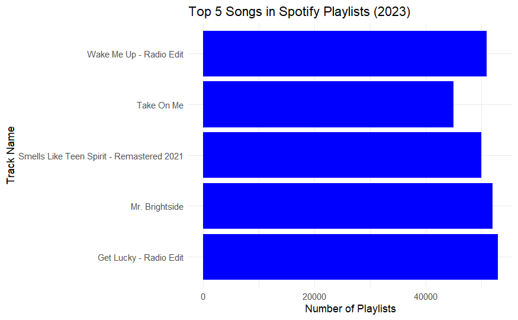

```r
ggplot(top5_2023, aes(x = track_name, y = in_spotify_playlists)) +
  geom_bar(stat = "identity", fill = "blue") +
  coord_flip() +
  labs(title = "Top 5 Songs in Spotify Playlists (2023)",
       x = "Track Name",
       y = "Number of Playlists") +
  theme_minimal()
```

In 2024, the 5 most popular songs in playlists were:

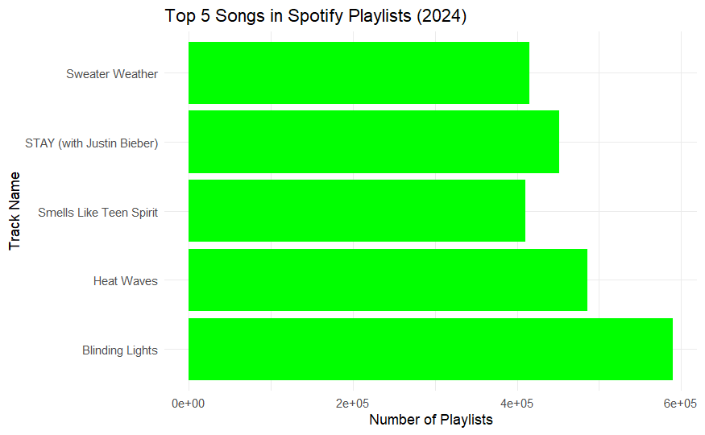

```r
ggplot(top5_2024, aes(x = Track, y = Spotify.Playlist.Count)) +
  geom_bar(stat = "identity", fill = "green") +
  coord_flip() +
  labs(title = "Top 5 Songs in Spotify Playlists (2024)",
       x = "Track Name",
       y = "Number of Playlists") +
  theme_minimal()
```

Visualization for correlation between bpm and popularity in 2023:

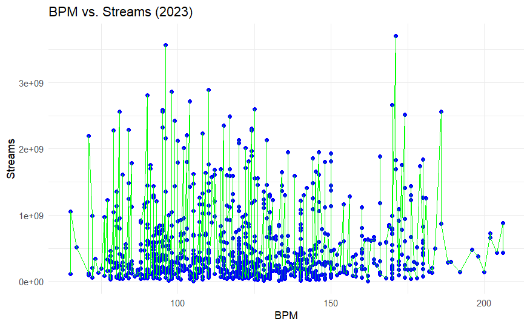

```r
ggplot(data2023_cleaned, aes(x = bpm, y = streams)) +
  geom_point(color = "blue") +
  geom_line(color = "green") +
  labs(title = "BPM vs. Streams (2023)",
       x = "BPM",
       y = "Streams") +
  theme_minimal()
```

The Final Visualization revolves around streams across platforms, we are going to arrange the data and visualize it accordingly.

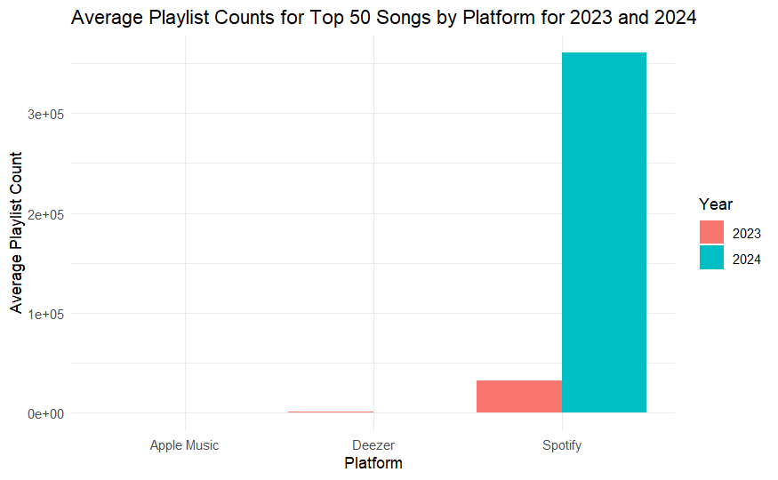

```r
top50_2023 <- data2023 %>%
  arrange(desc(in_spotify_playlists)) %>%
  head(50)

top50_2024 <- data2024 %>%
  arrange(desc(Spotify.Playlist.Count)) %>%
  head(50)

top50_2023_cleaned <- top50_2023 %>%
  rename(
    Spotify_Playlists = in_spotify_playlists,
    Apple_Music_Playlists = in_apple_playlists,
    Deezer_Playlists = in_deezer_playlists
  )

top50_2024_cleaned <- top50_2024 %>%
  rename(
    Spotify_Playlists = Spotify.Playlist.Count,
    Apple_Music_Playlists = Apple.Music.Playlist.Count,
    Deezer_Playlists = Deezer.Playlist.Count
  )

summary_2023 <- top50_2023_cleaned %>%
  summarise(
    Avg_Spotify_Playlists = mean(Spotify_Playlists, na.rm = TRUE),
    Avg_Apple_Music_Playlists = mean(Apple_Music_Playlists, na.rm = TRUE),
    Avg_Deezer_Playlists = mean(as.numeric(Deezer_Playlists), na.rm = TRUE)
  )
summary_2024 <- top50_2024_cleaned %>%
  summarise(
    Avg_Spotify_Playlists = mean(Spotify_Playlists, na.rm = TRUE),
    Avg_Apple_Music_Playlists = mean(Apple_Music_Playlists, na.rm = TRUE),
    Avg_Deezer_Playlists = mean(Deezer_Playlists, na.rm = TRUE)
  )

comparison_data <- bind_rows(
  data.frame(Year = "2023", Platform = "Spotify", Streams = summary_2023$Avg_Spotify_Playlists),
  data.frame(Year = "2023", Platform = "Apple Music", Streams = summary_2023$Avg_Apple_Music_Playlists),
  data.frame(Year = "2023", Platform = "Deezer", Streams = summary_2023$Avg_Deezer_Playlists),
  data.frame(Year = "2024", Platform = "Spotify", Streams = summary_2024$Avg_Spotify_Playlists),
  data.frame(Year = "2024", Platform = "Apple Music", Streams = summary_2024$Avg_Apple_Music_Playlists),
  data.frame(Year = "2024", Platform = "Deezer", Streams = summary_2024$Avg_Deezer_Playlists)
)

ggplot(comparison_data, aes(x = Platform, y = Streams, fill = Year)) +
  geom_bar(stat = "identity", position = "dodge") +
  labs(title = "Average Playlist Counts for Top 50 Songs by Platform for 2023 and 2024",
       x = "Platform",
       y = "Average Playlist Count") +
  theme_minimal()
```

## Conclusion

1. The 5 most popular songs in the 2023 playlist were(in increasing order of playlist presence):
1. Take on me
2. Smells Like Teen Spirit - Remastered 2021
3. Wake Me Up - Radio Edit
4. Mr. Brightside
5. Get Lucky - Radio Edit

The 5 most popular songs in the 2024 playlist were(in increasing order of playlist presence):

1. Smells Like Teen Spirit
2. Sweater Weather
3. STAY(with Justin Bieber)
4. Heat Waves
5. Blinding Lights
2. With regards to the BPM Vs Streams Correlation:

There seems to be a slightly negative correlation between BPM and Popularity of Songs, and the graph reflects that there is no correlation that proves that the higher the BPM of a song.

3. With regards to streams across platforms for the top 50 songs of 2023 and 2024, there is no surprise that Spotify has the vast majority of playlist utilizers. The top 50 songs in 2024 appear on playlists much more than the top 50 songs of 2023.

In addition to this, another point to note which was quite surprising is the fact that Deezer has more playlist users for top 50 songs than Apple Music in 2023. Apple Music managed to slightly exceed Deezer in 2024 however.

Listed below in tabular format are the numbers:

```r
comparison_data
```

| Year | Platform | Streams |
| --- | --- | --- |
| 2023 | Spotify | 32139.1000 |
| 2023 | Apple Music | 254.6000 |
| 2023 | Deezer | 770.6667 |
| 2024 | Spotify | 360712.1200 |
| 2024 | Apple Music | 269.1800 |
| 2024 | Deezer | 164.8800 |